# Analysis of breast cancer dataset

**Missing data**  
Most of missings concentrated on several rows, so I just drop the incomplete rows.

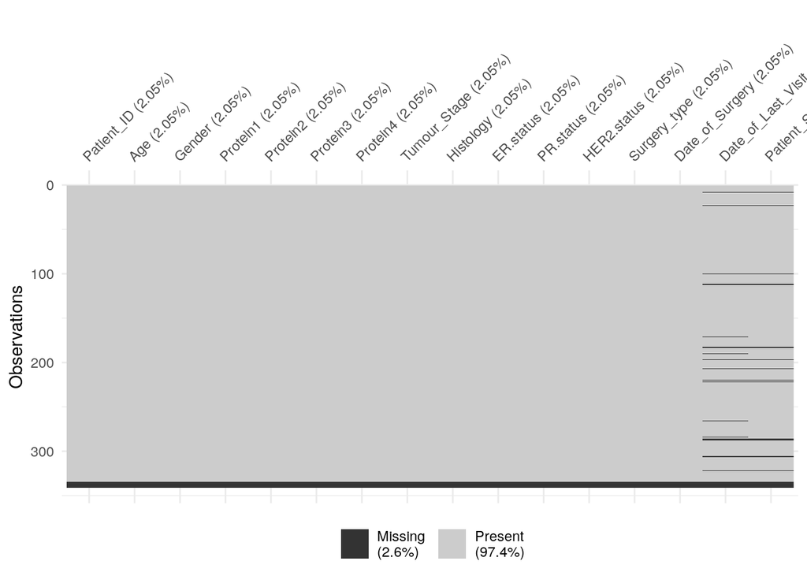

```
## 28 / 341  incomplete data are dropped
```

**Study population**  
Only females are included in this analysis.  
Because all ER/HER2 are positive, I only use PR+/PR- to classify the receptors

# Result

## Result 1: analysis of the risk factor of death

First, I found the potential factors by survival analysis. In the survival analysis, the effect of factors are measured by hazard ratio(HR) which is related to the survival time. Because it's a crude effect, there is no specific threshold of the p-values. Besides, this model does not aim to predict who are survivor, so I will also select the factors I'm interested in.

Following is the crude result of survival analysis. In my analysis, I used reference code, so the blank values means it's the reference, and all of the results are marginal means. For example, in the Tumour_Stage, HR = 2.63 means that the rate of dying of patients with stage III is 2.63 times those of stage I, on average.  
Univariable is the crude hazard ratio, and the multivariable is the adjusted effect(controlling for other variables). Here, I think the protein2, protein4, tumor stage and surgery type have potential association with survival experience. And there could be potential interaction among the proteins.

|  | Dependent: Surv(survdays,censor) |  | all | HR (univariable) | HR (multivariable) |
| --- | --- | --- | --- | --- | --- |
| 1 | Age | Mean (SD) | 58.7 (12.8) | 1.00 (0.98-1.02, p=0.843) | 1.01 (0.98-1.03, p=0.603) |
| 5 | Protein1 | Mean (SD) | -0.0 (0.5) | 0.95 (0.61-1.47, p=0.817) | 0.76 (0.47-1.25, p=0.280) |
| 6 | Protein2 | Mean (SD) | 0.9 (0.9) | 1.23 (0.92-1.65, p=0.157) | 1.38 (1.00-1.89, p=0.048) |
| 7 | Protein3 | Mean (SD) | -0.1 (0.6) | 1.06 (0.69-1.63, p=0.782) | 1.16 (0.73-1.83, p=0.526) |
| 8 | Protein4 | Mean (SD) | 0.0 (0.6) | 1.67 (1.07-2.60, p=0.025) | 1.83 (1.13-2.96, p=0.013) |
| 15 | Tumour_Stage | I | 60 (100.0) | - | - |
| 16 |  | II | 177 (100.0) | 1.58 (0.75-3.31, p=0.225) | 1.59 (0.74-3.38, p=0.233) |
| 17 |  | III | 76 (100.0) | 2.63 (1.15-6.02, p=0.022) | 2.73 (1.12-6.65, p=0.027) |
| 9 | receptor | PR- | 284 (100.0) | - | - |
| 10 |  | PR+ | 29 (100.0) | 0.99 (0.36-2.74, p=0.980) | 0.85 (0.29-2.46, p=0.765) |
| 14 | Surgery_type | Simple Mastectomy | 64 (100.0) | - | - |
| 11 |  | Lumpectomy | 66 (100.0) | 0.94 (0.39-2.28, p=0.890) | 0.80 (0.31-2.06, p=0.650) |
| 12 |  | Modified Radical Mastectomy | 87 (100.0) | 1.85 (0.86-4.01, p=0.117) | 1.50 (0.66-3.44, p=0.336) |
| 13 |  | Other | 96 (100.0) | 1.23 (0.60-2.52, p=0.579) | 1.08 (0.52-2.27, p=0.829) |
| 2 | Histology | Infiltrating Ductal Carcinoma | 222 (100.0) | - | - |
| 3 |  | Infiltrating Lobular Carcinoma | 79 (100.0) | 0.83 (0.44-1.54, p=0.546) | 0.73 (0.39-1.38, p=0.330) |
| 4 |  | Mucinous Carcinoma | 12 (100.0) | 1.06 (0.33-3.43, p=0.923) | 1.31 (0.38-4.57, p=0.672) |

Let me check the correlation among proteins and age. Obviously, some of them are correlated, but now I don't care about them.

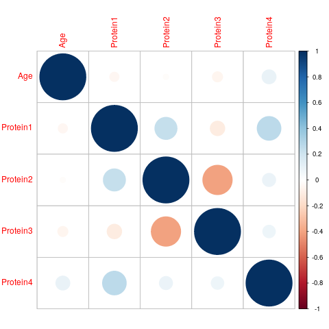

Figure 1

Finally, I choose this model. I believe the protein 4 is associated with the survival experience. It's adjusted by tumor stage, histology, and protein2.

|  | Dependent: Surv(survdays,censor) |  | all | HR (univariable) | HR (multivariable) |
| --- | --- | --- | --- | --- | --- |
| 5 | Protein4 | Mean (SD) | 0.0 (0.6) | 1.67 (1.07-2.60, p=0.025) | 1.71 (1.08-2.69, p=0.021) |
| 6 | Tumour_Stage | I | 60 (100.0) | - | - |
| 7 |  | II | 177 (100.0) | 1.58 (0.75-3.31, p=0.225) | 1.70 (0.81-3.57, p=0.162) |
| 8 |  | III | 76 (100.0) | 2.63 (1.15-6.02, p=0.022) | 3.05 (1.32-7.05, p=0.009) |
| 1 | Histology | Infiltrating Ductal Carcinoma | 222 (100.0) | - | - |
| 2 |  | Infiltrating Lobular Carcinoma | 79 (100.0) | 0.83 (0.44-1.54, p=0.546) | 0.73 (0.39-1.37, p=0.334) |
| 3 |  | Mucinous Carcinoma | 12 (100.0) | 1.06 (0.33-3.43, p=0.923) | 1.27 (0.39-4.19, p=0.692) |
| 4 | Protein2 | Mean (SD) | 0.9 (0.9) | 1.23 (0.92-1.65, p=0.157) | 1.25 (0.93-1.67, p=0.142) |

### Objective 2: find the treatment and the expectation

Generally, the treatment could be different because of the tumor stage. Here the surgery type and tumor stage are correlated.

```
##
##  Pearson's Chi-squared test
##
## data:  data$Surgery_type and data$Tumour_Stage
## X-squared = 31.363, df = 6, p-value = 2.161e-05
```

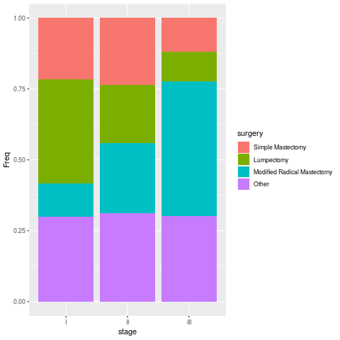

Figure 6

Just compare the mean effects of surgery type for different groups

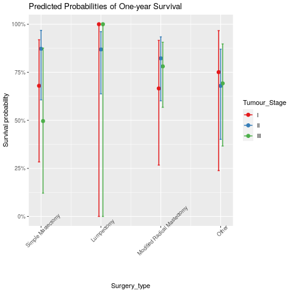

Figure 7